# DATA 624: PREDICTIVE ANALYTICS HW 7

Gabriel Campos

Last edited March 31, 2024

```r
library(fpp3)
library(dplyr)
library(ggplot2)
library(readxl)
library(tsibble)
library(psych)
library(tidyr)
library(forecast)
library(AppliedPredictiveModeling)
library(caret)
library(mice)
```

# Description

In Kuhn and Johnson do problems 6.2 and 6.3. There are only two but they consist of many parts. Please submit a link to your Rpubs and submit the .rmd file as well.

# 6.2

Developing a model to predict permeability (see Sect. 1.4) could save sig nificant resources for a pharmaceutical company, while at the same time more rapidly identifying molecules that have a sufficient permeability to become a drug:

## (a)

Start R and use these commands to load the data:

```r
# library(AppliedPredictiveModeling)
data(permeability)
```

The matrix fingerprints contains the 1,107 binary molecular predic tors for the 165 compounds, while permeability contains permeability response.

```r
describe(fingerprints)
```

|  | vars | n | mean | sd | median | trimmed | mad | min | max | range | skew | kurtosis | se |
| --- | --- | --- | --- | --- | --- | --- | --- | --- | --- | --- | --- | --- | --- |
| X1 | 1 | 165 | 0.23 | 0.42 | 0 | 0.17 | 0 | 0 | 1 | 1 | 1.27 | -0.39 | 0.03 |
| X2 | 2 | 165 | 0.22 | 0.42 | 0 | 0.16 | 0 | 0 | 1 | 1 | 1.31 | -0.28 | 0.03 |
| X3 | 3 | 165 | 0.21 | 0.41 | 0 | 0.14 | 0 | 0 | 1 | 1 | 1.40 | -0.05 | 0.03 |
| X4 | 4 | 165 | 0.21 | 0.41 | 0 | 0.14 | 0 | 0 | 1 | 1 | 1.40 | -0.05 | 0.03 |
| X5 | 5 | 165 | 0.21 | 0.41 | 0 | 0.14 | 0 | 0 | 1 | 1 | 1.40 | -0.05 | 0.03 |
| X6 | 6 | 165 | 0.45 | 0.50 | 0 | 0.44 | 0 | 0 | 1 | 1 | 0.21 | -1.97 | 0.04 |
| X7 | 7 | 165 | 1.00 | 0.00 | 1 | 1.00 | 0 | 1 | 1 | 0 | NaN | NaN | 0.00 |
| X8 | 8 | 165 | 1.00 | 0.00 | 1 | 1.00 | 0 | 1 | 1 | 0 | NaN | NaN | 0.00 |
| X9 | 9 | 165 | 0.02 | 0.13 | 0 | 0.00 | 0 | 0 | 1 | 1 | 7.15 | 49.38 | 0.01 |
| X10 | 10 | 165 | 0.02 | 0.15 | 0 | 0.00 | 0 | 0 | 1 | 1 | 6.13 | 35.80 | 0.01 |

[output cut: 990 more lines]

```r
str(fingerprints)
```

```
 num [1:165, 1:1107] 0 0 0 0 0 0 0 0 0 0 ...
 - attr(*, "dimnames")=List of 2
  ..$ : chr [1:165] "1" "2" "3" "4" ...
  ..$ : chr [1:1107] "X1" "X2" "X3" "X4" ...
```

```r
head(fingerprints)
```

[output not shown]

## (b)

The fingerprint predictors indicate the presence or absence of substructures of a molecule and are often sparse meaning that relatively few of the molecules contain each substructure. Filter out the predictors that have low frequencies using the nearZeroVar function from the caret package. How many predictors are left for modeling?

```r
ls_low_freq<- caret::nearZeroVar(fingerprints)
```

Use the list to remove the low freq values

```r
df_predictors<-fingerprints[,-ls_low_freq]
```

```r
dim(df_predictors)
```

```
[1] 165 388
```

388 predictors are observed excluding the low frequency ones

## (c)

Split the data into a training and a test set, pre-process the data, and tune a PLS model. How many latent variables are optimal and what is the corresponding resampled estimate of R2?

```r
set.seed(2341)

split_70_30<- sample(c(rep(0, 0.7 * nrow(permeability)),
                  rep(1, 0.3 * nrow(permeability))))

table(split_70_30)
```

```
split_70_30
  0   1
115  49
```

```r
perm_train <- df_predictors[split_70_30 == 0,]
perm_test <- df_predictors[split_70_30 == 1,]

permval_train <- permeability[split_70_30 == 0]
permval_test <- permeability[split_70_30 == 1]
```

```r
plsTune <- train(perm_train, permval_train,
                method='pls', metric='Rsquared',
                tuneLength=20,
                trControl=trainControl(method='cv'),
                preProc=c('center', 'scale')
                )
plsTune
```

```
Partial Least Squares

116 samples
388 predictors

Pre-processing: centered (388), scaled (388)
Resampling: Cross-Validated (10 fold)
Summary of sample sizes: 105, 104, 105, 105, 104, 104, ...
Resampling results across tuning parameters:

  ncomp  RMSE      Rsquared   MAE
   1     12.76379  0.3701181  9.649690
   2     11.48789  0.4929283  8.092644
   3     11.36269  0.4923943  8.498330
   4     11.53746  0.4776651  9.098205
   5     11.16207  0.5166155  8.428996
   6     10.91408  0.5660991  8.203404
   7     11.13978  0.5501549  8.411338
   8     11.27712  0.5399636  8.460640
   9     11.38287  0.5324154  8.511054
  10     11.29507  0.5565455  8.472403
  11     11.20997  0.5558190  8.602237
  12     11.33861  0.5481419  8.581228
  13     11.46362  0.5288650  8.642865
  14     11.54990  0.5243676  8.950729
  15     11.66521  0.5172820  9.004366
  16     11.87688  0.5059494  9.244973
  17     11.93235  0.5011155  9.338696
  18     11.97054  0.4986438  9.279785
  19     11.98435  0.4980171  9.304164
  20     12.05885  0.4976040  9.281354

Rsquared was used to select the optimal model using the largest value.
The final value used for the model was ncomp = 6.
```

## (d)

Predict the response for the test set. What is the test set estimate of R2?

```r
#generate prediction using model and testing data
plsPred <- predict(plsTune, newdata=perm_test)

#evaluation metrics
postResample(pred=plsPred, obs=permval_test)
```

```
      RMSE   Rsquared        MAE
12.5063133  0.3752582  8.7413544
```

## (e)

Try building other models discussed in this chapter. Do any have better predictive performance?

```r
set.seed(1432)

pcr_Tune <- train(perm_train, permval_train,
                   method = "pcr",
                   tuneLength = 20,
                   trControl = trainControl("cv"),
                   preProc=c('center', 'scale')
)

#pcr_Tune

#generate prediction using model and testing data
pcrPred <- predict(pcr_Tune, newdata=perm_test)

#evaluation metrics
postResample(pred=pcrPred, obs=permval_test)
```

```
      RMSE   Rsquared        MAE
13.3639435  0.2677629  9.7969544
```

```r
set.seed(3421)

enetGrid <- expand.grid(.lambda = c(0, 0.01, .1),
                        .fraction = seq(.05, 1, length = 20))

enet_Tune <- train(perm_train, permval_train,
                    method = "enet",
                    tuneGrid = enetGrid,
                    trControl = trainControl("cv"),
                    preProc = c("center", "scale"))

#enet_Tune

#generate prediction using model and testing data
enetPred <- predict(enet_Tune, newdata=perm_test)

#evaluation metrics
postResample(pred=enetPred, obs=permval_test)
```

```
      RMSE   Rsquared        MAE
13.0866776  0.3435946  8.8171072
```

## (f)

Would you recommend any of your models to replace the permeability laboratory experiment?

# 6.3.

A chemical manufacturing process for a pharmaceutical product was discussed in Sect. 1.4. In this problem, the objective is to understand the relationship between biological measurements of the raw materials (predictors), measurements of the manufacturing process (predictors), and the response of product yield. Biological predictors cannot be changed but can be used to assess the quality of the raw material before processing. On the other hand, manufacturing process predictors can be changed in the manufacturing process. Improving product yield by 1 % will boost revenue by approximately one hundred thousand dollars per batch:

## (a)

Start R and use these commands to load the data:

```r
#library(AppliedPredictiveModeling)
data(ChemicalManufacturingProcess)
```

The matrix `processPredictors` contains the 57 predictors (12 describing the input biological material and 45 describing the process predictors) for the 176 manufacturing runs. yield contains the percent yield for each run.

## (b)

A small percentage of cells in the predictor set contain missing values. Use an imputation function to fill in these missing values (e.g., see Sect. 3.8).

```r
df_impute <- mice(ChemicalManufacturingProcess, printFlag=F, method="cart", seed = 1)

df_imputed <- complete(df_impute)
```

## (c)

Split the data into a training and a test set, pre-process the data, and tune a model of your choice from this chapter. What is the optimal value of the performance metric?

```r
ls_low_freq_imputed <- nearZeroVar(df_imputed)


predictors_chem <- df_imputed[,-ls_low_freq_imputed]

#70 30 split
split_70_30_chem <- sample(c(rep(0, 0.7 * nrow(predictors_chem)),
                  rep(1, 0.3 * nrow(predictors_chem))))

#split the data
train_chem <- predictors_chem[split_70_30_chem == 0,]
test_chem <- predictors_chem[split_70_30_chem == 1,]

#PLS model
pls_chem <- train(Yield~., train_chem,
                method='pls', metric='Rsquared',
                tuneLength=30,
                trControl=trainControl(method='cv'),
                preProc=c('center', 'scale')
                )

pls_chem
```

```
Partial Least Squares

124 samples
 56 predictor

Pre-processing: centered (56), scaled (56)
Resampling: Cross-Validated (10 fold)
Summary of sample sizes: 112, 112, 112, 110, 111, 112, ...
Resampling results across tuning parameters:

  ncomp  RMSE      Rsquared   MAE
   1     1.529677  0.4010646  1.180821
   2     1.755482  0.4392847  1.190576
   3     1.512907  0.4935478  1.081644
   4     1.415093  0.5253042  1.061878
```

[output cut: 29 more lines]

**4 1.415093 0.5253042 1.061878**

## (d)

Predict the response for the test set. What is the value of the performance metric and how does this compare with the resampled performance metric on the training set?

```r
predict_chem = predict(pls_chem,test_chem)

postResample(pred = predict_chem, obs =test_chem$Yield)
```

```
     RMSE  Rsquared       MAE
1.6455102 0.4269652 1.1066459
```

The $R^2$ value lowered slightly on the `chem_test$Yield` data suggesting the model performed worse using test set than on the training set.

## (e)

Which predictors are most important in the model you have trained? Do either the biological or process predictors dominate the list?

Looks like Manufacturing process is slightly more important considering the top 6 most important predictors is ManufacturingProcess.

```r
varImp(pls_chem)
```

```
pls variable importance

  only 20 most important variables shown (out of 56)
```

|  | Overall |
| --- | --- |
| ManufacturingProcess32 | 100.00000 |
| ManufacturingProcess36 | 73.25863 |
| ManufacturingProcess09 | 69.83869 |
| ManufacturingProcess13 | 68.00199 |
| ManufacturingProcess33 | 60.93841 |
| ManufacturingProcess17 | 60.81090 |
| BiologicalMaterial03 | 53.70238 |
| BiologicalMaterial02 | 53.17155 |
| BiologicalMaterial06 | 52.87769 |
| BiologicalMaterial08 | 52.27525 |

[output cut: 10 more lines]

## (f)

Explore the relationships between each of the top predictors and the response. How could this information be helpful in improving yield in future runs of the manufacturing process?

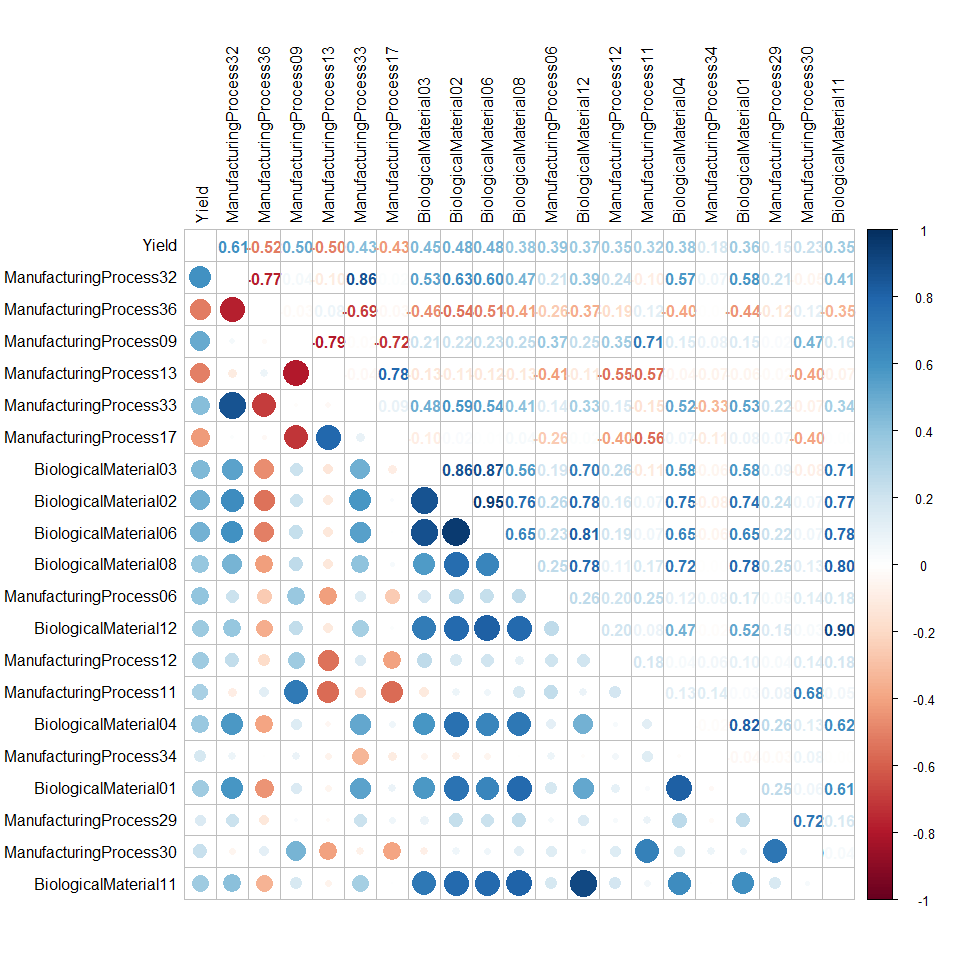

```r
corr_vals <- predictors_chem %>%
  select('Yield', "ManufacturingProcess32", "ManufacturingProcess36",
         "ManufacturingProcess09", "ManufacturingProcess13",
         "ManufacturingProcess33", "ManufacturingProcess17",
         "BiologicalMaterial03", "BiologicalMaterial02",
         "BiologicalMaterial06", "BiologicalMaterial08",
         "ManufacturingProcess06", "BiologicalMaterial12",
         "ManufacturingProcess12", "ManufacturingProcess11",
         "BiologicalMaterial04", "ManufacturingProcess34",
         "BiologicalMaterial01", "ManufacturingProcess29",
         "ManufacturingProcess30", "BiologicalMaterial11")

corr_plot_vals <- cor(corr_vals)

corrplot.mixed(corr_plot_vals, tl.col = 'black', tl.pos = 'lt',
         upper = "number", lower="circle")
```